# Practical Machine Learning : Course Project

Deepjyoti Chakraborty

11/9/2020

# Background

Using devices such as Jawbone Up, Nike FuelBand, and Fitbit it is now possible to collect a large amount of data about personal activity relatively inexpensively. These type of devices are part of the quantified self movement – a group of enthusiasts who take measurements about themselves regularly to improve their health, to find patterns in their behavior, or because they are tech geeks. One thing that people regularly do is quantify how much of a particular activity they do, but they rarely quantify how well they do it. In this project, our goal will be to use data from accelerometers on the belt, forearm, arm, and dumbell of 6 participants. They were asked to perform barbell lifts correctly and incorrectly in 5 different ways. More information is available from the website here: http://web.archive.org/web/20161224072740/http:/groupware.les.inf.puc-rio.br/har (see the section on the Weight Lifting Exercise Dataset).

We will use different modelling techniques to achieve the objective of predicting the manner in which they did the exercise which is given by the “classe” variable in the training data set. We will select the best model based on performance on testing data set created out of partitioning the training data set given in the project into training and testing data set. The testing data set given in the assignment is used as validation data set.

## Loading required libraries

## Downloading the files from the URLs given in the assignment

```r
download.file('https://d396qusza40orc.cloudfront.net/predmachlearn/pml-training.csv', destfile = './pml-training.csv')
download.file('https://d396qusza40orc.cloudfront.net/predmachlearn/pml-testing.csv', destfile = './pml-testing.csv')
```

## Loading dataset

```r
train_dataset <- read.csv('./pml-training.csv', header=T)
valid_dataset <- read.csv('./pml-testing.csv', header=T)
dim(train_dataset)
```

```
## [1] 19622   160
```

```r
dim(valid_dataset)
```

```
## [1]  20 160
```

## Checking variables in train_dataset

```r
head(train_dataset)
```

```
##   X user_name raw_timestamp_part_1 raw_timestamp_part_2   cvtd_timestamp
## 1 1  carlitos           1323084231               788290 05/12/2011 11:23
## 2 2  carlitos           1323084231               808298 05/12/2011 11:23
## 3 3  carlitos           1323084231               820366 05/12/2011 11:23
## 4 4  carlitos           1323084232               120339 05/12/2011 11:23
## 5 5  carlitos           1323084232               196328 05/12/2011 11:23
## 6 6  carlitos           1323084232               304277 05/12/2011 11:23
##   new_window num_window roll_belt pitch_belt yaw_belt total_accel_belt
## 1         no         11      1.41       8.07    -94.4                3
## 2         no         11      1.41       8.07    -94.4                3
## 3         no         11      1.42       8.07    -94.4                3
## 4         no         12      1.48       8.05    -94.4                3
## 5         no         12      1.48       8.07    -94.4                3
## 6         no         12      1.45       8.06    -94.4                3
##   kurtosis_roll_belt kurtosis_picth_belt kurtosis_yaw_belt skewness_roll_belt
```

[output cut: 251 more lines]

## Removing variables with NA values

```r
training<- train_dataset[, colSums(is.na(train_dataset)) == 0]
validation <- valid_dataset[, colSums(is.na(valid_dataset)) == 0]
dim(training)
```

```
## [1] 19622    93
```

```r
dim(validation)
```

```
## [1] 20 60
```

## Removing first 7 variables as they are not relevant

```r
training <- training[, -c(1:7)]
validation <- validation[, -c(1:7)]
dim(training)
```

```
## [1] 19622    86
```

```r
dim(validation)
```

```
## [1] 20 53
```

## Creating two data sets from training data set - training and testing

```r
set.seed(1234)
inTrain <- createDataPartition(training$classe, p = 0.7, list = FALSE)
training <- training[inTrain, ]
testing <- training[-inTrain, ]
dim(training)
```

```
## [1] 13737    86
```

```r
dim(testing)
```

```
## [1] 4123   86
```

## Removing variables with near zero variances from both training and testing data sets

```r
Near_Zero_Var <- nearZeroVar(training)
training <- training[, -Near_Zero_Var]
testing  <- testing[, -Near_Zero_Var]
dim(training)
```

```
## [1] 13737    53
```

```r
dim(testing)
```

```
## [1] 4123   53
```

## Mapping the correlation of variables in training dataset using corrplot function where we use RcolorBrewer package for color pallete and hierarchical clustering is used to order the variables

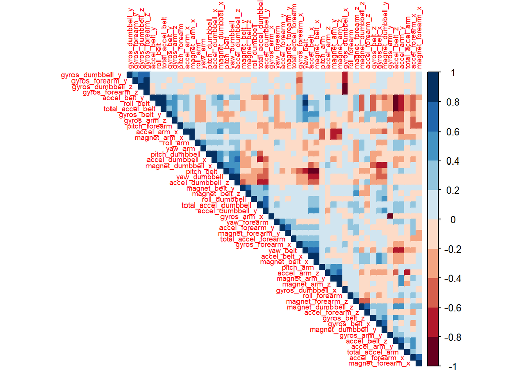

```r
corr_training <- cor(training[, -53])
corrplot(corr_training, order = "hclust", method = "color", type = "upper",
        col =  brewer.pal(n=10, name="RdBu"), tl.cex = 0.6 )
```

## Finding variables with correlation above 80%

```r
highcorrelation = findCorrelation(corr_training, cutoff=0.8)
names(training)[highcorrelation]
```

```
##  [1] "accel_belt_z"     "roll_belt"        "accel_belt_y"     "accel_dumbbell_z"
##  [5] "accel_belt_x"     "pitch_belt"       "accel_dumbbell_x" "accel_arm_x"
##  [9] "magnet_arm_y"     "gyros_forearm_y"  "gyros_dumbbell_x" "gyros_dumbbell_z"
## [13] "gyros_arm_x"
```

## Using a Decision tree model to predict “classe” variable in the testing data set with 5-fold cross validation

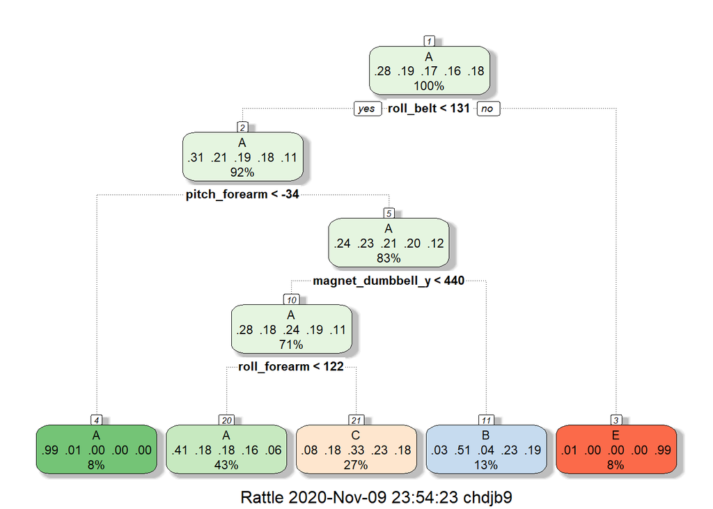

```r
set.seed(78910)
decisionTreeModel <- train(classe ~ ., data=training, method="rpart", trControl = trainControl(method = "cv", number = 5))
fancyRpartPlot(decisionTreeModel$finalModel)
```

```r
predictTreeModel <- predict(decisionTreeModel, testing)
confusionmatrixtree <- confusionMatrix(predictTreeModel, testing$classe)
confusionmatrixtree
```

```
## Confusion Matrix and Statistics
##
##           Reference
## Prediction    A    B    C    D    E
##          A 1058  336  346  292  117
##          B   21  245   22  113   91
##          C   82  206  370  267  210
##          D    0    0    0    0    0
##          E    4    0    0    0  343
##
## Overall Statistics
##
##                Accuracy : 0.489
##                  95% CI : (0.4736, 0.5043)
##     No Information Rate : 0.2826
##     P-Value [Acc > NIR] : < 2.2e-16
##
##                   Kappa : 0.3321
##
##  Mcnemar's Test P-Value : NA
##
## Statistics by Class:
##
##                      Class: A Class: B Class: C Class: D Class: E
## Sensitivity            0.9082  0.31131  0.50136    0.000  0.45072
## Specificity            0.6312  0.92596  0.77400    1.000  0.99881
## Pos Pred Value         0.4923  0.49797  0.32599      NaN  0.98847
## Neg Pred Value         0.9458  0.85073  0.87684    0.837  0.88930
## Prevalence             0.2826  0.19088  0.17900    0.163  0.18457
## Detection Rate         0.2566  0.05942  0.08974    0.000  0.08319
## Detection Prevalence   0.5212  0.11933  0.27528    0.000  0.08416
## Balanced Accuracy      0.7697  0.61863  0.63768    0.500  0.72477
```

## Using a Random Forest model to predict “classe” variable in the testing data set with 5-fold cross validation

```r
controlRandomForest <- trainControl(method="cv", number=5, verboseIter=FALSE)
modRandomForest <- train(classe ~ ., data=training, method="rf", trControl=controlRandomForest)
modRandomForest$finalModel
```

```
##
## Call:
##  randomForest(x = x, y = y, mtry = param$mtry)
##                Type of random forest: classification
##                      Number of trees: 500
## No. of variables tried at each split: 27
##
##         OOB estimate of  error rate: 0.7%
## Confusion matrix:
##      A    B    C    D    E class.error
## A 3901    3    0    0    2 0.001280082
## B   16 2636    5    1    0 0.008276900
## C    0   18 2369    9    0 0.011268781
## D    0    1   26 2223    2 0.012877442
## E    0    1    5    7 2512 0.005148515
```

```r
predictRandomForest <- predict(modRandomForest, newdata=testing)
confusionmatrixRandomForest <- confusionMatrix(predictRandomForest, testing$classe)
confusionmatrixRandomForest
```

```
## Confusion Matrix and Statistics
##
##           Reference
## Prediction    A    B    C    D    E
##          A 1165    0    0    0    0
##          B    0  787    0    0    0
##          C    0    0  738    0    0
##          D    0    0    0  672    0
##          E    0    0    0    0  761
##
## Overall Statistics
##
##                Accuracy : 1
##                  95% CI : (0.9991, 1)
##     No Information Rate : 0.2826
##     P-Value [Acc > NIR] : < 2.2e-16
##
##                   Kappa : 1
##
##  Mcnemar's Test P-Value : NA
##
## Statistics by Class:
##
##                      Class: A Class: B Class: C Class: D Class: E
## Sensitivity            1.0000   1.0000    1.000    1.000   1.0000
## Specificity            1.0000   1.0000    1.000    1.000   1.0000
## Pos Pred Value         1.0000   1.0000    1.000    1.000   1.0000
## Neg Pred Value         1.0000   1.0000    1.000    1.000   1.0000
## Prevalence             0.2826   0.1909    0.179    0.163   0.1846
## Detection Rate         0.2826   0.1909    0.179    0.163   0.1846
## Detection Prevalence   0.2826   0.1909    0.179    0.163   0.1846
## Balanced Accuracy      1.0000   1.0000    1.000    1.000   1.0000
```

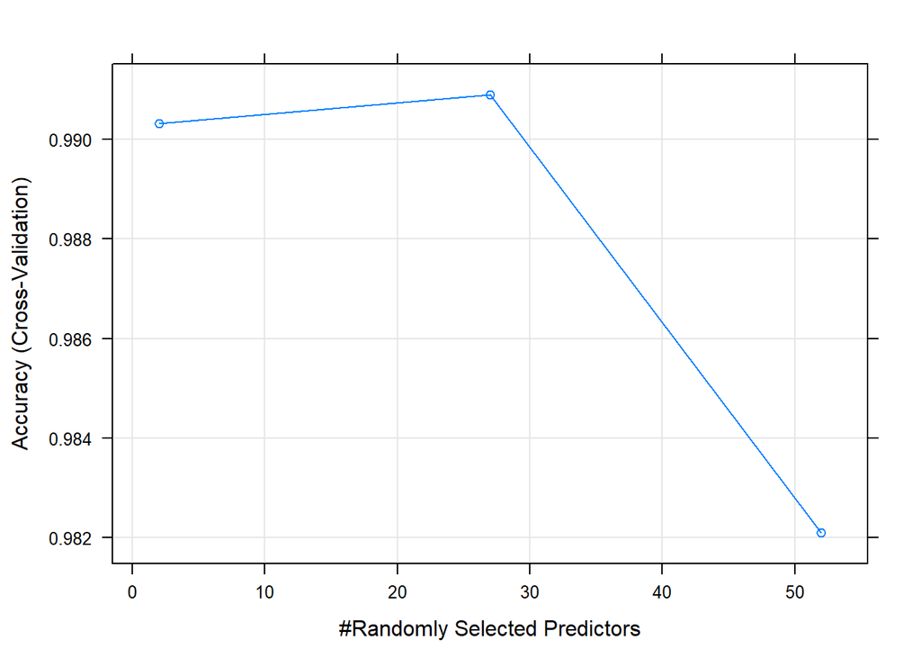

```r
plot(modRandomForest)
```

## Using a Gradient Boosted model to predict “classe” variable in the testing data set

```r
set.seed(78910)
controlGBM <- trainControl(method = "repeatedcv", number = 5, repeats = 2)
modGBM  <- train(classe ~ ., data=training, method = "gbm", trControl = controlGBM, verbose = FALSE)
modGBM$finalModel
```

```
## A gradient boosted model with multinomial loss function.
## 150 iterations were performed.
## There were 52 predictors of which 52 had non-zero influence.
```

```r
print(modGBM)
```

```
## Stochastic Gradient Boosting
##
## 13737 samples
##    52 predictor
##     5 classes: 'A', 'B', 'C', 'D', 'E'
##
## No pre-processing
## Resampling: Cross-Validated (5 fold, repeated 2 times)
## Summary of sample sizes: 10990, 10989, 10990, 10989, 10990, 10989, ...
## Resampling results across tuning parameters:
##
##   interaction.depth  n.trees  Accuracy   Kappa
##   1                   50      0.7508178  0.6840703
##   1                  100      0.8207033  0.7730875
##   1                  150      0.8525151  0.8133996
##   2                   50      0.8553535  0.8167416
##   2                  100      0.9038724  0.8783537
##   2                  150      0.9297151  0.9110543
##   3                   50      0.8944814  0.8664126
##   3                  100      0.9405252  0.9247369
##   3                  150      0.9597800  0.9491090
##
## Tuning parameter 'shrinkage' was held constant at a value of 0.1
##
## Tuning parameter 'n.minobsinnode' was held constant at a value of 10
## Accuracy was used to select the optimal model using the largest value.
## The final values used for the model were n.trees = 150, interaction.depth =
##  3, shrinkage = 0.1 and n.minobsinnode = 10.
```

```r
predictGBM <- predict(modGBM, newdata=testing)
confusionmatrixGBM <- confusionMatrix(predictGBM, testing$classe)
confusionmatrixGBM
```

```
## Confusion Matrix and Statistics
##
##           Reference
## Prediction    A    B    C    D    E
##          A 1161   20    0    0    1
##          B    2  754   20    0    5
##          C    2   13  709   15    3
##          D    0    0    7  651    9
##          E    0    0    2    6  743
##
## Overall Statistics
##
##                Accuracy : 0.9745
##                  95% CI : (0.9693, 0.9791)
##     No Information Rate : 0.2826
##     P-Value [Acc > NIR] : < 2.2e-16
##
##                   Kappa : 0.9678
##
##  Mcnemar's Test P-Value : NA
##
## Statistics by Class:
##
##                      Class: A Class: B Class: C Class: D Class: E
## Sensitivity            0.9966   0.9581   0.9607   0.9688   0.9763
## Specificity            0.9929   0.9919   0.9903   0.9954   0.9976
## Pos Pred Value         0.9822   0.9654   0.9555   0.9760   0.9893
## Neg Pred Value         0.9986   0.9901   0.9914   0.9939   0.9947
## Prevalence             0.2826   0.1909   0.1790   0.1630   0.1846
## Detection Rate         0.2816   0.1829   0.1720   0.1579   0.1802
## Detection Prevalence   0.2867   0.1894   0.1800   0.1618   0.1821
## Balanced Accuracy      0.9947   0.9750   0.9755   0.9821   0.9870
```

# Conclusion

```r
Results <- predict(modRandomForest, newdata=validation)
Results
```

```
##  [1] B A B A A E D B A A B C B A E E A B B B
## Levels: A B C D E
```